# Reference video

# Turnning Ensemble Ids to Gene symbols

## Human or mouse

**sanbomics 为视频作者创造的包**

https://github.com/mousepixels/sanbomics

plots: volcano: easily plot volcano plot from sanbomics.plots import volcano tools: id_map: map ensembl, entrez, and symbols between eachother from sanbomics.tools import id_map

```python
# %pip install sanbomics #视频作者创造的包，
# plots: volcano: easily plot volcano plot from sanbomics.plots import volcano tools: id_map: map ensembl, entrez, and symbols between eachother from sanbomics.tools import id_map


from sanbomics.tools import id_map
```

```python
# 选择物种
mapper = id_map(species = 'mouse')
```

```python
#基因转换
res['Symbol'] = res.index.map(mapper.mapper)
```

```python
res
```

| name | baseMean | log2FoldChange | lfcSE | stat | pvalue | padj | Symbol |
| --- | --- | --- | --- | --- | --- | --- | --- |
| ENSRNOG00000017646 | 0.991341 | 0.660860 | 1.700053 | 0.388729 | 0.697477 | NaN | NaN |
| ENSRNOG00000055917 | 656.411127 | -0.025619 | 0.077202 | -0.331843 | 0.740008 | 0.845056 | NaN |
| ENSRNOG00000023858 | 2.252295 | -3.828462 | 1.772278 | -2.160193 | 0.030758 | NaN | NaN |
| ENSRNOG00000023850 | 678.865131 | -0.056881 | 0.084419 | -0.673797 | 0.500440 | 0.671645 | NaN |
| ENSRNOG00000023851 | 1386.408122 | -0.106770 | 0.066001 | -1.617717 | 0.105724 | 0.227145 | NaN |
| ... | ... | ... | ... | ... | ... | ... | ... |
| ENSRNOG00000004198 | 284.277966 | 0.402567 | 0.113536 | 3.545707 | 0.000392 | 0.002559 | NaN |
| ENSRNOG00000004199 | 0.377442 | 2.031884 | 2.954214 | 0.687792 | 0.491584 | NaN | NaN |
| ENSRNOG00000060253 | 0.123483 | -0.735585 | 3.866966 | -0.190223 | 0.849135 | NaN | NaN |
| ENSRNOG00000007551 | 271.147199 | 0.223985 | 0.109923 | 2.037647 | 0.041585 | 0.112344 | NaN |
| ENSRNOG00000007558 | 1.425750 | 0.975590 | 1.620727 | 0.601946 | 0.547210 | NaN | NaN |

21539 rows × 7 columns

## All species

```python
# %pip install mygene
```

```python
import mygene

mg = mygene.MyGeneInfo()
```

```python
# 查询Ensembl ID对应的Gene Symbol
result = mg.querymany(res.index, scopes='ensembl.gene', species='rat')
```

```
7 input query terms found dup hits:	[('ENSRNOG00000057774', 2), ('ENSRNOG00000046216', 2), ('ENSRNOG00000005906', 2), ('ENSRNOG000000155
4016 input query terms found no hit:	['ENSRNOG00000042264', 'ENSRNOG00000038951', 'ENSRNOG00000053709', 'ENSRNOG00000044303', 'ENSRNOG000
```

```python
# 将查询结果转换为 DataFrame
result_df = pd.DataFrame(result)
result_df
```

|  | query | _id | _score | entrezgene | name | symbol | taxid | notfound |
| --- | --- | --- | --- | --- | --- | --- | --- | --- |
| 0 | ENSRNOG00000017646 | 361424 | 19.010834 | 361424 | similar to human chromosome 16 open reading fr... | C19h16orf74 | 10116.0 | NaN |
| 1 | ENSRNOG00000055917 | 291171 | 19.010603 | 291171 | tripartite motif-containing 27 | Trim27 | 10116.0 | NaN |
| 2 | ENSRNOG00000023858 | 363215 | 19.010664 | 363215 | protease, serine, 39 | Prss39 | 10116.0 | NaN |
| 3 | ENSRNOG00000023850 | 300521 | 19.010693 | 300521 | transforming growth factor beta regulator 1 | Tbrg1 | 10116.0 | NaN |
| 4 | ENSRNOG00000023851 | 295325 | 18.420029 | 295325 | immunoglobulin superfamily, member 3 | Igsf3 | 10116.0 | NaN |
| ... | ... | ... | ... | ... | ... | ... | ... | ... |
| 21542 | ENSRNOG00000004198 | 362734 | 19.010664 | 362734 | syntaxin binding protein 6 | Stxbp6 | 10116.0 | NaN |
| 21543 | ENSRNOG00000004199 | ENSRNOG00000004199 | 19.010664 | NaN | NaN | AABR07062753.1 | 10116.0 | NaN |
| 21544 | ENSRNOG00000060253 | 120096397 | 19.010687 | 120096397 | small nucleolar RNA SNORA17 | LOC120096397 | 10116.0 | NaN |
| 21545 | ENSRNOG00000007551 | 140581 | 18.420020 | 140581 | PATJ, crumbs cell polarity complex component | Patj | 10116.0 | NaN |
| 21546 | ENSRNOG00000007558 | ENSRNOG00000007558 | 19.010600 | NaN | defensin beta 36 | Defb36 | 10116.0 | NaN |

21547 rows × 8 columns

```python
# 保留查询中有用的列
result_df.index=result_df['query']
result_df = result_df[['entrezgene','symbol','name']]

#重命名
result_df=result_df.rename(columns={'symbol':'Symbol'})

result_df
```

| query | entrezgene | Symbol | name |
| --- | --- | --- | --- |
| ENSRNOG00000017646 | 361424 | C19h16orf74 | similar to human chromosome 16 open reading fr... |
| ENSRNOG00000055917 | 291171 | Trim27 | tripartite motif-containing 27 |
| ENSRNOG00000023858 | 363215 | Prss39 | protease, serine, 39 |
| ENSRNOG00000023850 | 300521 | Tbrg1 | transforming growth factor beta regulator 1 |
| ENSRNOG00000023851 | 295325 | Igsf3 | immunoglobulin superfamily, member 3 |
| ... | ... | ... | ... |
| ENSRNOG00000004198 | 362734 | Stxbp6 | syntaxin binding protein 6 |
| ENSRNOG00000004199 | NaN | AABR07062753.1 | NaN |
| ENSRNOG00000060253 | 120096397 | LOC120096397 | small nucleolar RNA SNORA17 |
| ENSRNOG00000007551 | 140581 | Patj | PATJ, crumbs cell polarity complex component |
| ENSRNOG00000007558 | NaN | Defb36 | defensin beta 36 |

21547 rows × 3 columns

```python
#表格合并
res = res.merge(result_df, left_index=True, right_index=True, how='right')
res
```

| name | baseMean | log2FoldChange | lfcSE | stat | pvalue | padj | entrezgene | Symbol | name |
| --- | --- | --- | --- | --- | --- | --- | --- | --- | --- |
| ENSRNOG00000017646 | 0.991341 | 0.660860 | 1.700053 | 0.388729 | 0.697477 | NaN | 361424 | C19h16orf74 | similar to human chromosome 16 open reading fr... |
| ENSRNOG00000055917 | 656.411127 | -0.025619 | 0.077202 | -0.331843 | 0.740008 | 0.845056 | 291171 | Trim27 | tripartite motif-containing 27 |
| ENSRNOG00000023858 | 2.252295 | -3.828462 | 1.772278 | -2.160193 | 0.030758 | NaN | 363215 | Prss39 | protease, serine, 39 |
| ENSRNOG00000023850 | 678.865131 | -0.056881 | 0.084419 | -0.673797 | 0.500440 | 0.671645 | 300521 | Tbrg1 | transforming growth factor beta regulator 1 |
| ENSRNOG00000023851 | 1386.408122 | -0.106770 | 0.066001 | -1.617717 | 0.105724 | 0.227145 | 295325 | Igsf3 | immunoglobulin superfamily, member 3 |
| ... | ... | ... | ... | ... | ... | ... | ... | ... | ... |
| ENSRNOG00000004198 | 284.277966 | 0.402567 | 0.113536 | 3.545707 | 0.000392 | 0.002559 | 362734 | Stxbp6 | syntaxin binding protein 6 |
| ENSRNOG00000004199 | 0.377442 | 2.031884 | 2.954214 | 0.687792 | 0.491584 | NaN | NaN | AABR07062753.1 | NaN |
| ENSRNOG00000060253 | 0.123483 | -0.735585 | 3.866966 | -0.190223 | 0.849135 | NaN | 120096397 | LOC120096397 | small nucleolar RNA SNORA17 |
| ENSRNOG00000007551 | 271.147199 | 0.223985 | 0.109923 | 2.037647 | 0.041585 | 0.112344 | 140581 | Patj | PATJ, crumbs cell polarity complex component |
| ENSRNOG00000007558 | 1.425750 | 0.975590 | 1.620727 | 0.601946 | 0.547210 | NaN | NaN | Defb36 | defensin beta 36 |

21547 rows × 9 columns

# Sig genes

```python
# 过滤表达量少的基因
res = res[res.baseMean >= 10]
```

```python
# 保存数据
res.to_csv('res.csv', index=True)
```

```python
# 过滤出差异基因
sigs = res[(res.padj < 0.05) & (abs(res.log2FoldChange) > math.log2(1.5))]
```

```python
sigs
```

[output not shown]

1069 rows × 12 columns

# Pca

```python
import scanpy as sc
```

```python
dds
```

[output not shown]

```python
sc.tl.pca(dds)
```

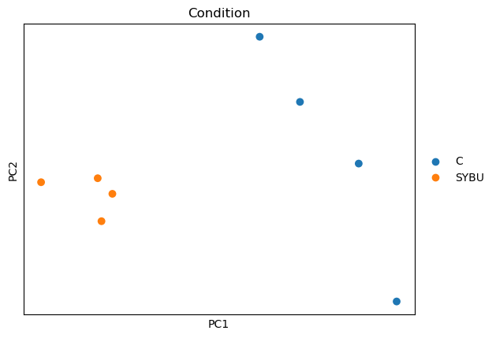

```python
sc.pl.pca(dds, color = 'Condition', size = 200)
```

# GSEA

gseapy是一个用于基因集合富集分析 (Gene Set Enrichment Analysis, GSEA) 的 Python 包

```python
# %pip install gseapy
```

```python
import gseapy as gp
from gseapy.plot import gseaplot
```

```python
res
```

[output not shown]

13708 rows × 12 columns

```python
# 提取基因名称 (Symbol) 和排名值 (stat)
ranking = res[['Symbol', 'stat']].dropna().sort_values('stat', ascending = False) #dropna() 是用于删除包含缺失值（NaN）的行或列的方法
ranking
```

| name | Symbol | stat |
| --- | --- | --- |
| ENSRNOG00000006151 | Reg3b | 22.666889 |
| ENSRNOG00000004200 | Sybu | 21.683383 |
| ENSRNOG00000030285 | Epha3 | 16.955553 |
| ENSRNOG00000050647 | Hspa1a | 16.866743 |
| ENSRNOG00000000902 | Hsph1 | 15.168636 |
| ... | ... | ... |
| ENSRNOG00000061910 | Igfbp3 | -23.855268 |
| ENSRNOG00000019598 | Vegfa | -24.111771 |
| ENSRNOG00000050585 | Pgam1 | -24.172277 |
| ENSRNOG00000001214 | Pfkl | -29.041197 |
| ENSRNOG00000005053 | Egln3 | -31.923541 |

12702 rows × 2 columns

```python
# 去除重复
ranking = ranking.drop_duplicates('Symbol')

#去除索引
ranking.reset_index(inplace=True)
ranking=ranking[['Symbol', 'stat']]
ranking
```

|  | Symbol | stat |
| --- | --- | --- |
| 0 | Reg3b | 22.666889 |
| 1 | Sybu | 21.683383 |
| 2 | Epha3 | 16.955553 |
| 3 | Hspa1a | 16.866743 |
| 4 | Hsph1 | 15.168636 |
| ... | ... | ... |
| 12679 | Igfbp3 | -23.855268 |
| 12680 | Vegfa | -24.111771 |
| 12681 | Pgam1 | -24.172277 |
| 12682 | Pfkl | -29.041197 |
| 12683 | Egln3 | -31.923541 |

12684 rows × 2 columns

**注意：做gp.prerank时要求只有2列Symbol与stat**

stat 通常指的是 Wald 统计量

Wald 统计量= 估计的log2 fold change/标准误差(lfcSE)

Wald 统计量计算 p 值的过程是通过标准化 log2 fold change，然后利用标准正态分布的累积分布函数来计算双尾 p 值。这些 p 值用于评估基因在不同条件下的表达差异是否显著

```
p=2⋅(1−Φ(∣Wald 统计量∣))，其中，Φ 是标准正态分布的累积分布函数（CDF）
```

```python
# 手动定义的基因集
manual_set = {'things':['Sybu', 'Hspa1a', 'Egln3', 'Pfkl', 'Vegfa']}
```

```python
gp.get_library_name()#to look at available libraries
```

```
['ARCHS4_Cell-lines',
 'ARCHS4_IDG_Coexp',
 'ARCHS4_Kinases_Coexp',
 'ARCHS4_TFs_Coexp',
 'ARCHS4_Tissues',
 'Achilles_fitness_decrease',
 'Achilles_fitness_increase',
 'Aging_Perturbations_from_GEO_down',
 'Aging_Perturbations_from_GEO_up',
 'Allen_Brain_Atlas_10x_scRNA_2021',
 'Allen_Brain_Atlas_down',
 'Allen_Brain_Atlas_up',
 'Azimuth_2023',
 'Azimuth_Cell_Types_2021',
 'BioCarta_2013',
 'BioCarta_2015',
 'BioCarta_2016',
 'BioPlanet_2019',
 'BioPlex_2017',
 'CCLE_Proteomics_2020',
 'CORUM',
 'COVID-19_Related_Gene_Sets',
 'COVID-19_Related_Gene_Sets_2021',
 'Cancer_Cell_Line_Encyclopedia',
 'CellMarker_2024',
 'CellMarker_Augmented_2021',
 'ChEA_2013',
 'ChEA_2015',
 'ChEA_2016',
 'ChEA_2022',
 'Chromosome_Location',
 'Chromosome_Location_hg19',
 'ClinVar_2019',
 'DSigDB',
 'Data_Acquisition_Method_Most_Popular_Genes',
 'DepMap_WG_CRISPR_Screens_Broad_CellLines_2019',
 'DepMap_WG_CRISPR_Screens_Sanger_CellLines_2019',
 'Descartes_Cell_Types_and_Tissue_2021',
 'Diabetes_Perturbations_GEO_2022',
 'DisGeNET',
```

[output cut: 171 more lines]

```
 'Virus-Host_PPI_P-HIPSTer_2020',
 'VirusMINT',
 'Virus_Perturbations_from_GEO_down',
 'Virus_Perturbations_from_GEO_up',
 'WikiPathway_2021_Human',
 'WikiPathway_2023_Human',
 'WikiPathways_2013',
 'WikiPathways_2015',
 'WikiPathways_2016',
 'WikiPathways_2019_Human',
 'WikiPathways_2019_Mouse',
 'dbGaP',
 'huMAP',
 'lncHUB_lncRNA_Co-Expression',
 'miRTarBase_2017']
```

```python
pre_res = gp.prerank(rnk = ranking,
                     gene_sets = [ 'WikiPathways_2019_Mouse',manual_set], #输入基因集集合
                     seed = 6,  #随机种子，用于结果的可重复性
                     permutation_num = 100,#置换次数
                    min_size=4)
```

```
2024-07-23 09:56:13,799 [WARNING] Duplicated values found in preranked stats: 0.03% of genes
The order of those genes will be arbitrary, which may produce unexpected results.
```

**置换次数？**

置换次数 (permutation number) 是一个非常重要的参数，它直接影响了GSEA结果的准确性和稳定性。置换次数越多，结果越可靠，但计算时间也会相应增加

举例说明

假设你有一组基因表达数据，并计算了基因集合的富集得分：

实际得分: 观察到的基因集合富集得分是 2.5。

置换分析: 将基因表达数据随机打乱1000次，每次重新计算富集得分，得到一组富集得分的置换分布。

p 值计算: 假设置换分布中的得分大于2.5的次数为10次，则 p 值为 10/1000 = 0.01。

结果解释: p 值为0.01表示，随机情况下得分超过2.5的概率仅为1%，表明实际结果显著。

在实际分析中，推荐将 permutation_num 设置为1000或更多，以确保分析结果的稳定性和准确性。如果计算资源允许，设置更高的置换次数（如2000或5000）可以进一步提高结果的可靠性

**随机种子？**

计算机实际上不能生成真正的随机数，因为它们是确定性机器，但它们可以生成伪随机数，即通过某种算法生成看似随机的数列。这些算法被称为伪随机数生成器（PRNG, Pseudo-Random Number Generator）。随机种子是PRNG的初始值，决定了随机数序列的起点

随机种子是PRNG的初始值。只要种子值相同，PRNG每次生成的数列就相同

在科学研究和调试中，确保实验和测试的可重复性非常重要。使用相同的种子值，可以保证每次运行时生成的随机数序列相同,设置随机种子确保每次运行代码时结果一致

```python
# 通过loop 输出结果
out = []

for term in list(pre_res.results):
    out.append([term,
               pre_res.results[term]['fdr'],
               pre_res.results[term]['es'],
               pre_res.results[term]['nes']])

out_df = pd.DataFrame(out, columns = ['Term','fdr', 'es', 'nes']).sort_values('fdr').reset_index(drop = True)
out_df
```

|  | Term | fdr | es | nes |
| --- | --- | --- | --- | --- |
| 0 | WikiPathways_2019_Mouse__Oxidative phosphoryla... | 0.000000 | 0.807969 | 1.863101 |
| 1 | WikiPathways_2019_Mouse__Electron Transport Ch... | 0.000000 | 0.792334 | 1.839192 |
| 2 | 1__things | 0.302222 | -0.688094 | -1.357457 |
| 3 | WikiPathways_2019_Mouse__Complement and Coagul... | 0.795556 | -0.385961 | -0.726348 |

```python
# 排序并获取 NES 值最大的基因集名称
term=out_df.sort_values('nes').iloc[-1].Term #iloc 来访问特定位置的行或列
term
```

```
'WikiPathways_2019_Mouse__Oxidative phosphorylation WP1248'
```

```
[<Axes: xlabel='Gene Rank', ylabel='Ranked metric'>,
 <Axes: >,
 <Axes: >,
 <Axes: ylabel='Enrichment Score'>]
```

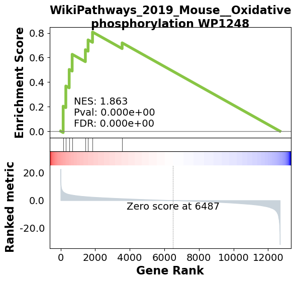

```python
# 画gsea图
gseaplot(rank_metric=pre_res.ranking, term=term, **pre_res.results[term])
```

# Heatmap

```python
import numpy as np
import seaborn as sns #使用它来创建美观的统计图表
```

```python
# 获取标准化表达矩阵
dds.layers['normed_counts']
```

```
array([[  0.        , 695.07843546,   0.        , ...,   0.        ,
        228.61996286,   2.76556407],
       [  2.13646435, 623.84759079,   1.06823218, ...,   0.        ,
        231.80638219,   1.06823218],
       [  0.98786631, 650.01603164,  10.8665294 , ...,   0.98786631,
        266.72390356,   0.        ],
       ...,
       [  1.89574979, 622.75380714,   0.        , ...,   0.        ,
        288.1539686 ,   3.79149959],
       [  1.02029723, 636.66547193,   0.        , ...,   0.        ,
        293.84560243,   0.        ],
       [  0.        , 669.71790956,   0.        , ...,   0.        ,
        305.94648616,   0.        ]])
```

```python
# 对标准表达矩阵进行scale
dds.layers['log1p'] = np.log1p(dds.layers['normed_counts'])
dds.layers['log1p']
```

```
array([[0.        , 6.54546235, 0.        , ..., 0.        , 5.43642561,
        1.32589767],
       [1.14309616, 6.43750777, 0.72669422, ..., 0.        , 5.45020713,
        0.72669422],
       [0.68706186, 6.47853427, 2.47372178, ..., 0.68706186, 5.58995624,
        0.        ],
       ...,
       [1.06324407, 6.43575575, 0.        , ..., 0.        , 5.66695931,
        1.56684343],
       [0.70324464, 6.45781381, 0.        , ..., 0.        , 5.68645184,
        0.        ],
       [0.        , 6.50834865, 0.        , ..., 0.        , 5.72667342,
        0.        ]])
```

## 差异基因heatmap

```python
#获取差异基因AnnData对象
dds_sigs = dds[:, sigs.index]
dds_sigs
```

```
View of AnnData object with n_obs × n_vars = 8 × 1069
    obs: 'Condition'
    uns: 'trend_coeffs', 'disp_function_type', '_squared_logres', 'prior_disp_var', 'pca', 'Condition_colors'
    obsm: 'design_matrix', 'size_factors', '_mu_LFC', '_hat_diagonals', 'replaceable', 'X_pca'
    varm: '_normed_means', 'non_zero', '_MoM_dispersions', 'genewise_dispersions', '_genewise_converged', 'fitted_dispersions', 'MAP_dispersions', '_MAP_converged', 'dispersions', '_outlier_genes', 'LFC', '_LFC_converged', 'replaced', 'refitted', 'PCs'
    layers: 'normed_counts', '_mu_hat', 'cooks', 'log1p'
```

```python
# 画热图
grapher = pd.DataFrame(dds_sigs.layers['log1p'].T,
                       index=dds_sigs.var_names, columns=dds_sigs.obs_names)
```

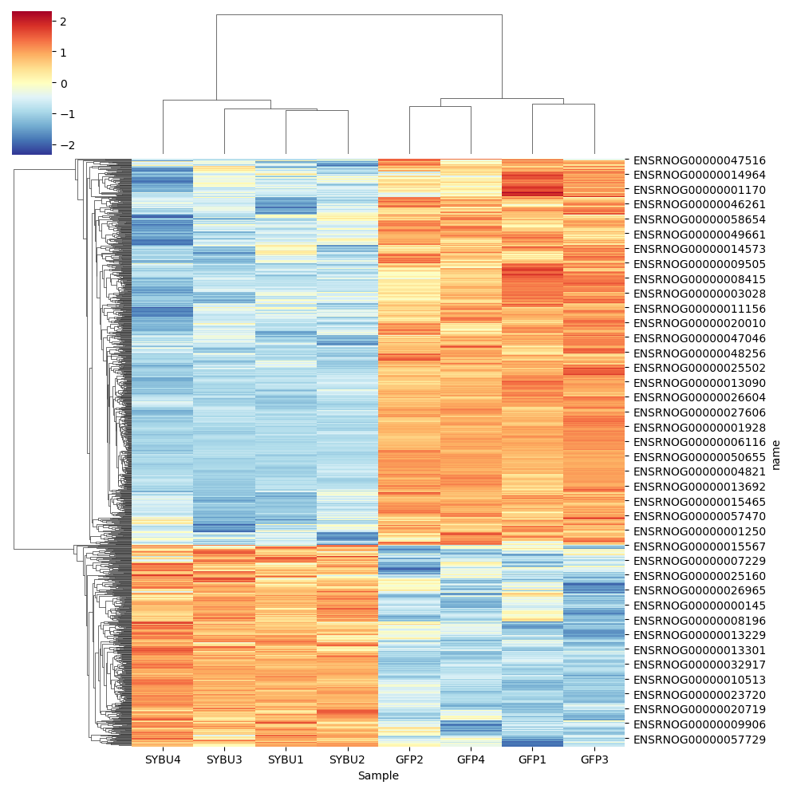

```python
sns.clustermap(grapher, z_score=0, cmap = 'RdYlBu_r')
# z_score=0 参数可以对行（即基因）进行标准化，这意味着每个基因的表达值都将被标准化为均值为0，标准差为1
# cmap='RdYlBu_r'：使用红-黄-蓝反转色图
```

## 特定基因heatmap

```python
with open('senGPT.txt') as f:
    senGPT = [x.strip() for x in list(f)]
```

senGPT为衰老相关的gene

```python
senGPT
```

```
['CDKN2A',
 'CDKN1A',
 'CDKN2B',
 'IL6',
 'IL8',
 'CXCL1',
 'CXCL2',
 'CXCL3',
 'CXCL5',
 'CXCL6',
 'MMP1',
 'MMP2',
 'MMP3',
 'MMP9',
 'MMP10',
 'MMP12',
 'MMP13',
 'MMP14',
 'SERPINE1',
 'IGFBP7',
 'SASP',
 'CCND1',
 'CCNE1',
 'BCL2',
 'BAX',
 'IL1A',
 'IL1B',
 'IL10',
 'TNF',
 'TGFB1',
 'CCL2',
 'CCL5',
 'CCL20',
 'ICAM1',
 'VCAM1',
 'RELA',
 'STAT1',
 'STAT3',
 'HIF1A',
 'PTGS2',
```

[output cut: 45 more lines]

```
 'RB1',
 'E2F1',
 'E2F2',
 'E2F3',
 'CCND2',
 'CCND3',
 'FOXO1',
 'FOXO3',
 'FOXO4',
 'HSPB1',
 'PML',
 'SAHF',
 'DDIT3',
 'XBP1',
 'ATF6']
```

```python
# 改大小写
senGPT = [word.title() for word in senGPT]

senGPT
```

```
['Cdkn2A',
 'Cdkn1A',
 'Cdkn2B',
 'Il6',
 'Il8',
 'Cxcl1',
 'Cxcl2',
 'Cxcl3',
 'Cxcl5',
 'Cxcl6',
 'Mmp1',
 'Mmp2',
 'Mmp3',
 'Mmp9',
 'Mmp10',
 'Mmp12',
 'Mmp13',
 'Mmp14',
 'Serpine1',
 'Igfbp7',
 'Sasp',
 'Ccnd1',
 'Ccne1',
 'Bcl2',
 'Bax',
 'Il1A',
 'Il1B',
 'Il10',
 'Tnf',
 'Tgfb1',
 'Ccl2',
 'Ccl5',
 'Ccl20',
 'Icam1',
 'Vcam1',
 'Rela',
 'Stat1',
 'Stat3',
 'Hif1A',
 'Ptgs2',
```

[output cut: 45 more lines]

```
 'Rb1',
 'E2F1',
 'E2F2',
 'E2F3',
 'Ccnd2',
 'Ccnd3',
 'Foxo1',
 'Foxo3',
 'Foxo4',
 'Hspb1',
 'Pml',
 'Sahf',
 'Ddit3',
 'Xbp1',
 'Atf6']
```

```python
# 提取emsemble-id
sigs[sigs.Symbol.isin(senGPT)].index
```

```
Index(['ENSRNOG00000002802', 'ENSRNOG00000007159', 'ENSRNOG00000014361',
       'ENSRNOG00000061910', 'ENSRNOG00000013925', 'ENSRNOG00000032626',
       'ENSRNOG00000051592', 'ENSRNOG00000047940', 'ENSRNOG00000016957',
       'ENSRNOG00000032832'],
      dtype='object', name='name')
```

```python
#获取特定基因AnnData对象
dds_sub = dds[:, sigs[sigs.Symbol.isin(senGPT)].index]
```

```python
# 画热图
grapher = pd.DataFrame(dds_sub.layers['log1p'].T,
                       index=dds_sub.var_names, columns=dds_sub.obs_names)
```

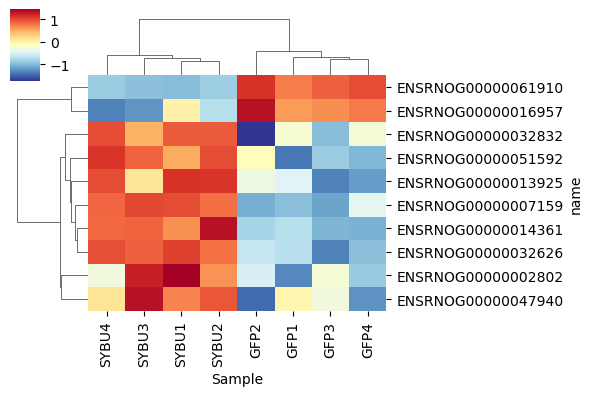

```python
sns.clustermap(grapher, z_score=0, cmap = 'RdYlBu_r',figsize=(6,4))
# z_score=0 参数可以对行（即基因）进行标准化，这意味着每个基因的表达值都将被标准化为均值为0，标准差为1
# cmap='RdYlBu_r'：使用红-黄-蓝反转色图
```

### All species geneId transform of heatmap

```python
grapher
```

| Sample name | GFP1 | GFP2 | GFP3 | GFP4 | SYBU1 | SYBU2 | SYBU3 | SYBU4 |
| --- | --- | --- | --- | --- | --- | --- | --- | --- |
| ENSRNOG00000002802 | 2.867523 | 3.241394 | 3.355511 | 3.070546 | 4.163977 | 3.776303 | 4.062796 | 3.344113 |
| ENSRNOG00000007159 | 5.711904 | 5.682544 | 5.664588 | 5.867871 | 6.260886 | 6.206154 | 6.268098 | 6.221686 |
| ENSRNOG00000014361 | 4.779102 | 4.756767 | 4.706401 | 4.699885 | 5.085619 | 5.245060 | 5.137969 | 5.131188 |
| ENSRNOG00000061910 | 7.237228 | 7.617158 | 7.376128 | 7.477953 | 5.571446 | 5.689647 | 5.595968 | 5.688268 |
| ENSRNOG00000013925 | 4.326385 | 4.355589 | 4.098867 | 4.137740 | 4.731591 | 4.726053 | 4.474210 | 4.694008 |
| ENSRNOG00000032626 | 4.544436 | 4.576162 | 4.250645 | 4.421424 | 5.337507 | 5.219749 | 5.256430 | 5.296854 |
| ENSRNOG00000051592 | 5.256578 | 5.607018 | 5.399493 | 5.359896 | 5.778597 | 5.910188 | 5.875109 | 5.944355 |
| ENSRNOG00000047940 | 4.030895 | 3.529743 | 3.939272 | 3.610078 | 4.288175 | 4.365970 | 4.508507 | 4.092281 |
| ENSRNOG00000016957 | 4.763487 | 5.035375 | 4.783684 | 4.822875 | 4.549366 | 4.290987 | 4.097294 | 4.056531 |
| ENSRNOG00000032832 | 3.179984 | 2.458077 | 2.821728 | 3.161630 | 3.729123 | 3.731906 | 3.515999 | 3.762467 |

```python
# 查询Ensembl ID对应的Gene Symbol
result = mg.querymany(grapher.index, scopes='ensembl.gene', species='rat')
```

```python
# 将查询结果转换为 DataFrame
result_df = pd.DataFrame(result)
result_df
```

|  | query | _id | _score | entrezgene | name | symbol | taxid |
| --- | --- | --- | --- | --- | --- | --- | --- |
| 0 | ENSRNOG00000002802 | 81503 | 19.010687 | 81503 | C-X-C motif chemokine ligand 1 | Cxcl1 | 10116 |
| 1 | ENSRNOG00000007159 | 24770 | 18.420027 | 24770 | C-C motif chemokine ligand 2 | Ccl2 | 10116 |
| 2 | ENSRNOG00000014361 | 24323 | 19.010695 | 24323 | endothelin 1 | Edn1 | 10116 |
| 3 | ENSRNOG00000061910 | 24484 | 19.010664 | 24484 | insulin-like growth factor binding protein 3 | Igfbp3 | 10116 |
| 4 | ENSRNOG00000013925 | 85431 | 18.419538 | 85431 | NADPH oxidase 4 | Nox4 | 10116 |
| 5 | ENSRNOG00000032626 | 171045 | 18.419928 | 171045 | matrix metallopeptidase 3 | Mmp3 | 10116 |
| 6 | ENSRNOG00000051592 | 309757 | 17.740270 | 309757 | sirtuin 1 | Sirt1 | 10116 |
| 7 | ENSRNOG00000047940 | 303384 | 19.010834 | 303384 | matrix metallopeptidase 28 | Mmp28 | 10116 |
| 8 | ENSRNOG00000016957 | 25662 | 19.010603 | 25662 | insulin-like growth factor binding protein 2 | Igfbp2 | 10116 |
| 9 | ENSRNOG00000032832 | 117061 | 19.010240 | 117061 | matrix metallopeptidase 10 | Mmp10 | 10116 |

```python
# 保留查询中有用的列
result_df.index=result_df['query']
result_df = result_df[['symbol']]

#重命名
result_df=result_df.rename(columns={'symbol':'Symbol'})

result_df
```

| query | Symbol |
| --- | --- |
| ENSRNOG00000002802 | Cxcl1 |
| ENSRNOG00000007159 | Ccl2 |
| ENSRNOG00000014361 | Edn1 |
| ENSRNOG00000061910 | Igfbp3 |
| ENSRNOG00000013925 | Nox4 |
| ENSRNOG00000032626 | Mmp3 |
| ENSRNOG00000051592 | Sirt1 |
| ENSRNOG00000047940 | Mmp28 |
| ENSRNOG00000016957 | Igfbp2 |
| ENSRNOG00000032832 | Mmp10 |

```python
#表格合并
grapher = grapher.merge(result_df, left_index=True, right_index=True, how='right')
grapher
```

| query | GFP1 | GFP2 | GFP3 | GFP4 | SYBU1 | SYBU2 | SYBU3 | SYBU4 | Symbol |
| --- | --- | --- | --- | --- | --- | --- | --- | --- | --- |
| ENSRNOG00000002802 | 2.867523 | 3.241394 | 3.355511 | 3.070546 | 4.163977 | 3.776303 | 4.062796 | 3.344113 | Cxcl1 |
| ENSRNOG00000007159 | 5.711904 | 5.682544 | 5.664588 | 5.867871 | 6.260886 | 6.206154 | 6.268098 | 6.221686 | Ccl2 |
| ENSRNOG00000014361 | 4.779102 | 4.756767 | 4.706401 | 4.699885 | 5.085619 | 5.245060 | 5.137969 | 5.131188 | Edn1 |
| ENSRNOG00000061910 | 7.237228 | 7.617158 | 7.376128 | 7.477953 | 5.571446 | 5.689647 | 5.595968 | 5.688268 | Igfbp3 |
| ENSRNOG00000013925 | 4.326385 | 4.355589 | 4.098867 | 4.137740 | 4.731591 | 4.726053 | 4.474210 | 4.694008 | Nox4 |
| ENSRNOG00000032626 | 4.544436 | 4.576162 | 4.250645 | 4.421424 | 5.337507 | 5.219749 | 5.256430 | 5.296854 | Mmp3 |
| ENSRNOG00000051592 | 5.256578 | 5.607018 | 5.399493 | 5.359896 | 5.778597 | 5.910188 | 5.875109 | 5.944355 | Sirt1 |
| ENSRNOG00000047940 | 4.030895 | 3.529743 | 3.939272 | 3.610078 | 4.288175 | 4.365970 | 4.508507 | 4.092281 | Mmp28 |
| ENSRNOG00000016957 | 4.763487 | 5.035375 | 4.783684 | 4.822875 | 4.549366 | 4.290987 | 4.097294 | 4.056531 | Igfbp2 |
| ENSRNOG00000032832 | 3.179984 | 2.458077 | 2.821728 | 3.161630 | 3.729123 | 3.731906 | 3.515999 | 3.762467 | Mmp10 |

```python
grapher.index=grapher['Symbol']
grapher
```

| Symbol | GFP1 | GFP2 | GFP3 | GFP4 | SYBU1 | SYBU2 | SYBU3 | SYBU4 | Symbol |
| --- | --- | --- | --- | --- | --- | --- | --- | --- | --- |
| Cxcl1 | 2.867523 | 3.241394 | 3.355511 | 3.070546 | 4.163977 | 3.776303 | 4.062796 | 3.344113 | Cxcl1 |
| Ccl2 | 5.711904 | 5.682544 | 5.664588 | 5.867871 | 6.260886 | 6.206154 | 6.268098 | 6.221686 | Ccl2 |
| Edn1 | 4.779102 | 4.756767 | 4.706401 | 4.699885 | 5.085619 | 5.245060 | 5.137969 | 5.131188 | Edn1 |
| Igfbp3 | 7.237228 | 7.617158 | 7.376128 | 7.477953 | 5.571446 | 5.689647 | 5.595968 | 5.688268 | Igfbp3 |
| Nox4 | 4.326385 | 4.355589 | 4.098867 | 4.137740 | 4.731591 | 4.726053 | 4.474210 | 4.694008 | Nox4 |
| Mmp3 | 4.544436 | 4.576162 | 4.250645 | 4.421424 | 5.337507 | 5.219749 | 5.256430 | 5.296854 | Mmp3 |
| Sirt1 | 5.256578 | 5.607018 | 5.399493 | 5.359896 | 5.778597 | 5.910188 | 5.875109 | 5.944355 | Sirt1 |
| Mmp28 | 4.030895 | 3.529743 | 3.939272 | 3.610078 | 4.288175 | 4.365970 | 4.508507 | 4.092281 | Mmp28 |
| Igfbp2 | 4.763487 | 5.035375 | 4.783684 | 4.822875 | 4.549366 | 4.290987 | 4.097294 | 4.056531 | Igfbp2 |
| Mmp10 | 3.179984 | 2.458077 | 2.821728 | 3.161630 | 3.729123 | 3.731906 | 3.515999 | 3.762467 | Mmp10 |

```python
grapher=grapher.drop(columns=['Symbol'])
grapher
```

| Symbol | GFP1 | GFP2 | GFP3 | GFP4 | SYBU1 | SYBU2 | SYBU3 | SYBU4 |
| --- | --- | --- | --- | --- | --- | --- | --- | --- |
| Cxcl1 | 2.867523 | 3.241394 | 3.355511 | 3.070546 | 4.163977 | 3.776303 | 4.062796 | 3.344113 |
| Ccl2 | 5.711904 | 5.682544 | 5.664588 | 5.867871 | 6.260886 | 6.206154 | 6.268098 | 6.221686 |
| Edn1 | 4.779102 | 4.756767 | 4.706401 | 4.699885 | 5.085619 | 5.245060 | 5.137969 | 5.131188 |
| Igfbp3 | 7.237228 | 7.617158 | 7.376128 | 7.477953 | 5.571446 | 5.689647 | 5.595968 | 5.688268 |
| Nox4 | 4.326385 | 4.355589 | 4.098867 | 4.137740 | 4.731591 | 4.726053 | 4.474210 | 4.694008 |
| Mmp3 | 4.544436 | 4.576162 | 4.250645 | 4.421424 | 5.337507 | 5.219749 | 5.256430 | 5.296854 |
| Sirt1 | 5.256578 | 5.607018 | 5.399493 | 5.359896 | 5.778597 | 5.910188 | 5.875109 | 5.944355 |
| Mmp28 | 4.030895 | 3.529743 | 3.939272 | 3.610078 | 4.288175 | 4.365970 | 4.508507 | 4.092281 |
| Igfbp2 | 4.763487 | 5.035375 | 4.783684 | 4.822875 | 4.549366 | 4.290987 | 4.097294 | 4.056531 |
| Mmp10 | 3.179984 | 2.458077 | 2.821728 | 3.161630 | 3.729123 | 3.731906 | 3.515999 | 3.762467 |

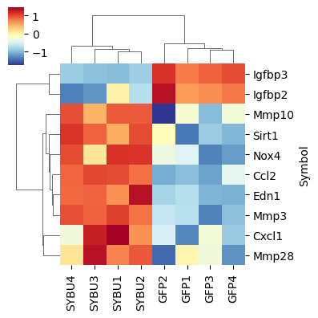

```python
ax = sns.clustermap(grapher, z_score=0, cmap = 'RdYlBu_r', figsize=(4,4))
```

# volcano

```python
from sanbomics.plots import volcano
```

```python
res
```

| name | baseMean | log2FoldChange | lfcSE | stat | pvalue | padj | entrezgene | Symbol | name |
| --- | --- | --- | --- | --- | --- | --- | --- | --- | --- |
| ENSRNOG00000055917 | 656.411127 | -0.025619 | 0.077202 | -0.331843 | 0.740008 | 0.845056 | 291171 | Trim27 | tripartite motif-containing 27 |
| ENSRNOG00000023850 | 678.865131 | -0.056881 | 0.084419 | -0.673797 | 0.500440 | 0.671645 | 300521 | Tbrg1 | transforming growth factor beta regulator 1 |
| ENSRNOG00000023851 | 1386.408122 | -0.106770 | 0.066001 | -1.617717 | 0.105724 | 0.227145 | 295325 | Igsf3 | immunoglobulin superfamily, member 3 |
| ENSRNOG00000017647 | 99.833751 | 0.182112 | 0.187238 | 0.972623 | 0.330741 | 0.510156 | 311414 | Zc3h8 | zinc finger CCCH type containing 8 |
| ENSRNOG00000042261 | 1239.268316 | 0.009056 | 0.086781 | 0.104359 | 0.916885 | 0.954674 | 114499 | Hdgf | heparin binding growth factor |
| ... | ... | ... | ... | ... | ... | ... | ... | ... | ... |
| ENSRNOG00000004197 | 139.696154 | 0.654008 | 0.145434 | 4.496945 | 0.000007 | 0.000077 | 503446 | Asb12 | ankyrin repeat and SOCS box-containing 12 |
| ENSRNOG00000004195 | 288.260573 | 0.163192 | 0.118766 | 1.374069 | 0.169420 | 0.319881 | 305073 | Dtl | denticleless E3 ubiquitin protein ligase homolog |
| ENSRNOG00000023639 | 178.229480 | 0.023368 | 0.154510 | 0.151241 | 0.879785 | 0.932952 | 287148 | Rpusd1 | RNA pseudouridine synthase domain containing 1 |
| ENSRNOG00000004198 | 284.277966 | 0.402567 | 0.113536 | 3.545707 | 0.000392 | 0.002559 | 362734 | Stxbp6 | syntaxin binding protein 6 |
| ENSRNOG00000007551 | 271.147199 | 0.223985 | 0.109923 | 2.037647 | 0.041585 | 0.112344 | 140581 | Patj | PATJ, crumbs cell polarity complex component |

13700 rows × 9 columns

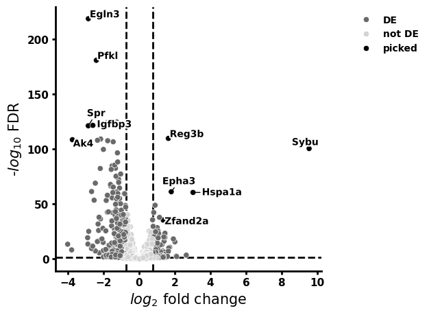

```python
volcano(res, symbol='Symbol')
```

## 标记特定基因

```python
grapher.index
```

```
Index(['Cxcl1', 'Ccl2', 'Edn1', 'Igfbp3', 'Nox4', 'Mmp3', 'Sirt1', 'Mmp28',
       'Igfbp2', 'Mmp10'],
      dtype='object', name='Symbol')
```

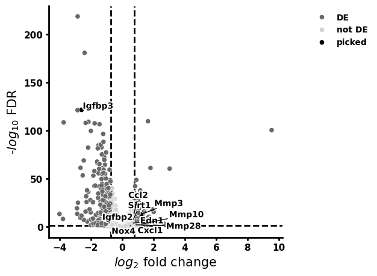

```python
volcano(res, symbol='Symbol', to_label = grapher.index)
```